# Dépendances des packages R sur Github

Pour chaque paquet collecté sur CRAN, Github, Bioconductor et R-Forge, nous allons récupérer la liste des dépendances dans les champs "Depends" et "Imports", et étudier la répartition de ces dépendances dans les différentes communautés. En plus de ces différentes communautés, certains packages (apparaissant dans les dépendances) sont des paquets fournis par défaut avec une distribution R. Ces paquets sont les suivants :

```python
"""
R_pkg = ('R MASS Matrix base boot class cluster codetools compiler datasets foreign grDevices ' +
        'graphics grid lattice manipulate methods mgcv nlme nnet parallel rpart rstudio' +
        'spatial splines stats stats4 stringr survival tcltk tools translations utils').split(' ')
"""
R_pkg = ('R, base, compiler, datasets, graphics, '
         'grDevices, grid, methods, parallel, profile, splines, stats, stats4, '
         'tcltk, tools, translations, utils').split(', ')

sources = ['cran', 'bioconductor', 'github', 'rforge']
```

```python
%matplotlib inline
from IPython.display import set_matplotlib_formats
import matplotlib.pyplot as plt
#set_matplotlib_formats('pdf')
```

```python
import pandas

df = pandas.DataFrame.from_csv('../data/R-Packages.csv')
df = df.fillna(value={'Depends': '', 'Imports': ''})

df = df.drop('profile')
```

La fonction suivante va récupérer les dépendances dans les champs "Depends" et "Imports" d'une série. Le parsing est naif, mais devrait matcher les paquets existants.

```python
def parse_dependencies(item):
    depends = item['Depends'] if item['Depends'] != pandas.np.nan else ''
    imports = item['Imports'] if item['Imports'] != pandas.np.nan else ''
    f = lambda lst: [dep.split('(')[0].strip() for dep in lst.split(',')]
    return filter(lambda x: len(x) > 0, f(depends) + f(imports))
```

La classe suivante sert de base à notre graphe. Les attributs sont :

- `name`: nom du package
- `sources`: liste des sources où ce paquet peut être trouvé
- `source`: source principale (dans l'ordre indiqué)
- `dependencies`: liste des dépendances (attendu : instances de `Package`)

La méthode `add_source` permet d'ajouter une source (`str`). La liste `dependencies` peut être manipulée directement.

```python
class Package(object):
    sources = ['R', 'cran', 'bioconductor', 'github', 'rforge']

    def __init__(self, name):
        self.name = name
        self.sources = []
        self.dependencies = {}

    def add_source(self, source):
        if source not in self.sources:
            self.sources.append(source)

    @property
    def source(self):
        for source in Package.sources:
            if source in self.sources:
                return source
        return 'Unknown'

    def pprint(self):
        return str(self) + ' -> ' + ', '.join(map(str, self.dependencies.itervalues()))

    def __unicode__(self):
        return '{name} on [{sources}]'.format(name=self.name, sources=', '.join(self.sources))
    __str__ = __repr__ = __unicode__
```

Pour chaque paquet identifié, nous ajoutons ces sources. Le dictionnaire `packages` vise à associer à chaque nom de paquet une instance de la classe `Package`.

```python
packages = {}

for name, data in df.iterrows():
    p = Package(name)
    for source in sources:
        if data[source] == 1:
            p.add_source(source)
    packages[name] = p
```

Ajoutons *R* dans les sources avec les packages correspondants.

```python
sources.append('R')

for name in R_pkg:
    # new data:
    p = Package(name)
    # keep existing data:
    # p = packages.setdefault(name, Package(name))

    p.add_source('R')
    packages[name] = p
```

Ajoutons les dépendances. Si le paquet n'est pas connu de notre liste de paquets, nous créons tout de même une instance de `Package`. La source associée à ce paquet sera automatiquement *Unknown* et ce paquet pourra donc être utilisé de façon transparente lors des calculs sur le graphe.

```python
for name, data in df.iterrows():
    p = packages[name]
    for dep in parse_dependencies(data):
        p_dep = packages.setdefault(dep, Package(dep))
        p.dependencies[p_dep.name] = p_dep
```

Enfin, il nous reste à créer le graphe dirigé. Ce graphe est construit classiquement pour les dépendances. A noter que les dépendances de la source *Unknown* sont également dans ce graphe (qui n'est naturellement pas une composante connexe).

```python
import networkx

dg = networkx.DiGraph()
for package in packages.itervalues():
    dg.add_node(package)
    for dependency in package.dependencies.itervalues():
        dg.add_edge(package, dependency)
```

## Centralité

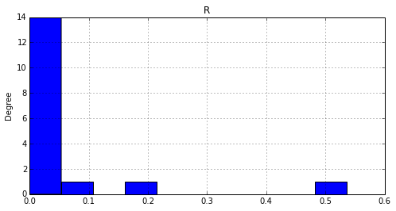

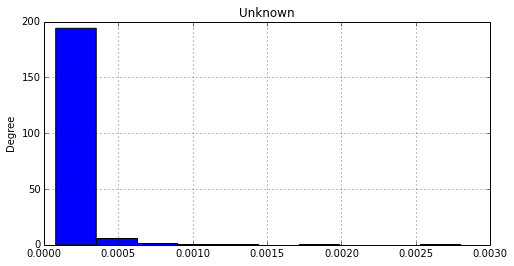

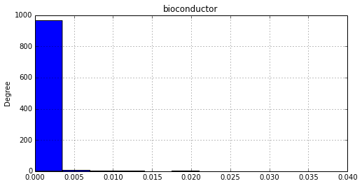

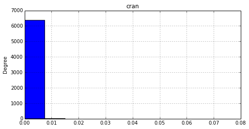

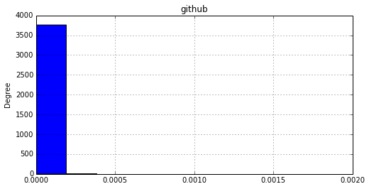

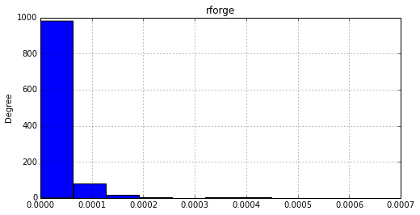

```python
def d2df(gd):
    m = {}
    for package, value in gd.iteritems():
        m[package.name] = {'source': package.source, 'value': value}
    return pandas.DataFrame.from_dict(m, orient='index')

for name, group in d2df(networkx.in_degree_centrality(dg)).groupby(by='source'):
    fig = plt.figure()
    ax = fig.add_subplot(111)
    group['value'].plot(kind='hist', figsize=(8,4), bins=10, title=name, ax=ax)
```

## Direction des dépendances

Pour chaque source de packages, nous allons regarder les différents paquets présents dans cette source. Pour chaque paquet, nous regardons les dépendances de ce paquet et la source principale de chacune de ces dépendances. Une liste $S(x,y)$ est calculée pour chaque paire $(x,y)$ de sources. Cette liste contient l'ensemble des paquets de $x$ qui ont au moins une dépendance dans $y$.

```python
S = {s:{s2: set() for s2 in sources + ['Unknown']} for s in sources}
```

```python
sources_needed_for = lambda p: set(map(lambda p: p.source, p.dependencies.itervalues()))

for p in packages.itervalues():
    for source in sources_needed_for(p):
        S[p.source][source].add(p)
```

```python
scores = {s: {s2: len(S[s][s2]) for s2 in S[s].iterkeys()} for s in S.iterkeys()}
```

Le tableau suivant reprend, pour chaque ligne, le nombre de paquets ayant au moins une dépendance vers la source indiquée en colonne.

```python
pandas.DataFrame.from_dict(scores).T
```

|  | R | Unknown | bioconductor | cran | github | rforge |
| --- | --- | --- | --- | --- | --- | --- |
| R | 0 | 0 | 0 | 0 | 0 | 0 |
| bioconductor | 899 | 99 | 725 | 694 | 1 | 1 |
| cran | 4283 | 18 | 86 | 4345 | 1 | 2 |
| github | 2056 | 157 | 251 | 2593 | 291 | 14 |
| rforge | 716 | 29 | 43 | 712 | 12 | 104 |

Quels sont les paquets "inconnus" ?

```python
map(lambda p: p.name, filter(lambda p: p.source == 'Unknown', packages.itervalues()))
```

```
['Rcompression',
 'BSgenome.Ecoli.NCBI.20080805',
 'hgu133a2.db',
 'BSgenome.Celegans.UCSC.ce2',
 'nnclust',
 'R.basic',
 'mvpart',
 'DRI',
 'rstudio',
 'intCNGEan',
 'geneLenDataBase',
 'fibroEset',
 'locfdr',
 'fastread',
 'lumiHumanAll.db',
 'RevoScaleR',
 'getmfclstuff',
 'jit',
 'RAmazonS3',
 'COHCAPanno',
 'randomSurvivalForest',
 'ChAMPdata',
 'FLFleet',
 'gist',
 'mirbase.db',
 'IlluminaHumanMethylation27k.db',
 'org.MeSH.Syn.db',
 'SVGAnnotation',
 'USGSwsGraphs',
 'ReadImages',
 'ts',
 'targetPredictor.db',
 'IlluminaHumanMethylation450kanno.ilmn12.hg19',
 'ITALICSData',
 'MetShot',
 'minfiData',
 'hgu133plus2.db',
 'org.MeSH.Bsu.168.db',
 'MUGAExampleData',
 'seqCNA.annot',
```

[output cut: 151 more lines]

```
 'NARSShared',
 'Rsge',
 'MeSH.PCR.db',
 'hapsim',
 'BSgenome.Scerevisiae.UCSC.sacCer2',
 'DrugVsDiseasedata',
 'ALL',
 'Filenames',
 'ChIPXpressData',
 'TxDb.Hsapiens.UCSC.hg19.knownGene',
 'utter',
 'hthgu133acdf',
 'parathyroidSE',
 'Currently no dependancies',
 'smwrStats']
```

## Dépendances les plus fréquentes par source

```python
dg2 = dg.copy()
dg2.remove_nodes_from(filter(lambda n: n.source == 'Unknown' or n.source == 'R', dg2.nodes_iter()))
in_degrees = [n for n in dg2.in_degree_iter()]
in_degrees.sort(key=lambda n: n[1], reverse=True)
```

La liste suivante reprend les dépendances apparaissant le plus fréquemment pour chaque source de packages. La liste *primarily* indique que ce package a comme source principale la source concernée. La liste *also available* indique que ce paquet est **notamment** disponible sur la source concernée. Notez bien que ce sont les dépendances de toutes les sources vers une source spécifique. Pour une liste des dépendances de chaque source, regardez (bien) plus bas.

```python
for source in ['cran', 'bioconductor', 'github', 'rforge']:
    print 'Most frequent dependency, for all packages, primarily on', source
    _ = filter(lambda x: x[0].source == source, in_degrees)[:10]
    print '\n'.join([str(n[0]) + ' : ' + str(n[1]) for n in _])
    print
```

```
Most frequent dependency, for all packages, primarily on cran
ggplot2 on [cran, github] : 938
MASS on [cran] : 918
plyr on [cran, github] : 772
Rcpp on [cran, rforge] : 667
stringr on [cran, github] : 483
lattice on [cran, rforge] : 475
Matrix on [cran, rforge] : 466
reshape2 on [cran, github] : 458
XML on [cran] : 444
RCurl on [cran] : 426

Most frequent dependency, for all packages, primarily on bioconductor
Biobase on [bioconductor] : 438
IRanges on [bioconductor, github] : 250
GenomicRanges on [bioconductor, github] : 226
BiocGenerics on [bioconductor] : 205
Biostrings on [bioconductor] : 171
AnnotationDbi on [bioconductor] : 132
S4Vectors on [bioconductor] : 104
Rsamtools on [bioconductor] : 101
affy on [bioconductor] : 85
rtracklayer on [bioconductor] : 66

Most frequent dependency, for all packages, primarily on github
FLCore on [github, rforge] : 24
opal on [github] : 9
rCharts on [github] : 8
wtsUtilities on [github] : 8
mjcbase on [github] : 8
SqlRender on [github] : 6
DatabaseConnector on [github] : 6
rccmisc on [github] : 5
stringtools on [github] : 5
CodeDepends on [github] : 4

Most frequent dependency, for all packages, primarily on rforge
oompaBase on [rforge] : 8
twMisc on [rforge] : 5
addendum on [rforge] : 5
FLash on [rforge] : 5
easydb on [rforge] : 4
ant on [rforge] : 4
twDEMC on [rforge] : 4
ClassDiscovery on [rforge] : 3
PortfolioAnalytics on [rforge] : 3
eatTools on [rforge] : 3
```

```python
for source in ['cran', 'bioconductor', 'github', 'rforge']:
    print 'Most frequent dependency, for all packages, available on', source
    _ = filter(lambda x: source in x[0].sources, in_degrees)[:10]
    print '\n'.join([str(n[0]) + ' : ' + str(n[1]) for n in _])
    print
```

```
Most frequent dependency, for all packages, available on cran
ggplot2 on [cran, github] : 938
MASS on [cran] : 918
plyr on [cran, github] : 772
Rcpp on [cran, rforge] : 667
stringr on [cran, github] : 483
lattice on [cran, rforge] : 475
Matrix on [cran, rforge] : 466
reshape2 on [cran, github] : 458
XML on [cran] : 444
RCurl on [cran] : 426

Most frequent dependency, for all packages, available on bioconductor
Biobase on [bioconductor] : 438
IRanges on [bioconductor, github] : 250
GenomicRanges on [bioconductor, github] : 226
BiocGenerics on [bioconductor] : 205
Biostrings on [bioconductor] : 171
limma on [cran, bioconductor] : 143
AnnotationDbi on [bioconductor] : 132
graph on [cran, bioconductor] : 114
S4Vectors on [bioconductor] : 104
Rsamtools on [bioconductor] : 101

Most frequent dependency, for all packages, available on github
ggplot2 on [cran, github] : 938
plyr on [cran, github] : 772
stringr on [cran, github] : 483
reshape2 on [cran, github] : 458
survival on [cran, github, rforge] : 298
httr on [cran, github] : 266
dplyr on [cran, github] : 261
IRanges on [bioconductor, github] : 250
GenomicRanges on [bioconductor, github] : 226
zoo on [cran, github, rforge] : 196

Most frequent dependency, for all packages, available on rforge
Rcpp on [cran, rforge] : 667
lattice on [cran, rforge] : 475
Matrix on [cran, rforge] : 466
mvtnorm on [cran, rforge] : 343
sp on [cran, rforge] : 303
survival on [cran, github, rforge] : 298
data.table on [cran, rforge] : 284
foreach on [cran, rforge] : 206
zoo on [cran, github, rforge] : 196
ape on [cran, rforge] : 191
```

La liste suivante reprend, pour chaque communauté, les dépendances les plus fréquentes (toute source confondue).

```python
from collections import Counter

for source in ['cran', 'bioconductor', 'github', 'rforge']:
    pkgs = filter(lambda x: x.source == source, packages.itervalues())
    deps = []
    for pkg in pkgs:
        _ = filter(lambda x: x.source != 'R' and x.source != 'Unknown', pkg.dependencies.itervalues())
        deps.extend(_)
    print 'Most frequent dependency for packages in', source
    print '\n'.join([str(n[0]) + ' : ' + str(n[1]) for n in Counter(deps).most_common(10)])
    print
```

```
Most frequent dependency for packages in cran
MASS on [cran] : 635
Rcpp on [cran, rforge] : 339
Matrix on [cran, rforge] : 308
ggplot2 on [cran, github] : 294
lattice on [cran, rforge] : 290
mvtnorm on [cran, rforge] : 258
plyr on [cran, github] : 251
survival on [cran, github, rforge] : 226
sp on [cran, rforge] : 166
XML on [cran] : 146

Most frequent dependency for packages in bioconductor
Biobase on [bioconductor] : 350
IRanges on [bioconductor, github] : 183
BiocGenerics on [bioconductor] : 180
GenomicRanges on [bioconductor, github] : 154
Biostrings on [bioconductor] : 106
AnnotationDbi on [bioconductor] : 99
limma on [cran, bioconductor] : 96
S4Vectors on [bioconductor] : 93
MASS on [cran] : 76
Rsamtools on [bioconductor] : 76

Most frequent dependency for packages in github
ggplot2 on [cran, github] : 539
plyr on [cran, github] : 434
stringr on [cran, github] : 312
reshape2 on [cran, github] : 273
RCurl on [cran] : 238
Rcpp on [cran, rforge] : 229
XML on [cran] : 216
dplyr on [cran, github] : 214
data.table on [cran, rforge] : 196
httr on [cran, github] : 182

Most frequent dependency for packages in rforge
MASS on [cran] : 81
lattice on [cran, rforge] : 61
Rcpp on [cran, rforge] : 59
plyr on [cran, github] : 43
Matrix on [cran, rforge] : 39
rJava on [cran] : 35
sp on [cran, rforge] : 34
ggplot2 on [cran, github] : 34
XML on [cran] : 33
raster on [cran, rforge] : 31
```